# Unsupervised Lab Session

## Learning outcomes:

- Exploratory data analysis and data preparation for model building.
- PCA for dimensionality reduction.
- K-means and Agglomerative Clustering

## Problem Statement

Based on the given marketing campigan dataset, segment the similar customers into suitable clusters. Analyze the clusters and provide your insights to help the organization promote their business.

## Context:

- Customer Personality Analysis is a detailed analysis of a company’s ideal customers. It helps a business to better understand its customers and makes it easier for them to modify products according to the specific needs, behaviors and concerns of different types of customers.
- Customer personality analysis helps a business to modify its product based on its target customers from different types of customer segments. For example, instead of spending money to market a new product to every customer in the company’s database, a company can analyze which customer segment is most likely to buy the product and then market the product only on that particular segment.

## About dataset

- Source: https://www.kaggle.com/datasets/imakash3011/customer-personality-analysis?datasetId=1546318&sortBy=voteCount

### Attribute Information:

- ID: Customer's unique identifier
- Year_Birth: Customer's birth year
- Education: Customer's education level
- Marital_Status: Customer's marital status
- Income: Customer's yearly household income
- Kidhome: Number of children in customer's household
- Teenhome: Number of teenagers in customer's household
- Dt_Customer: Date of customer's enrollment with the company
- Recency: Number of days since customer's last purchase
- Complain: 1 if the customer complained in the last 2 years, 0 otherwise
- MntWines: Amount spent on wine in last 2 years
- MntFruits: Amount spent on fruits in last 2 years
- MntMeatProducts: Amount spent on meat in last 2 years
- MntFishProducts: Amount spent on fish in last 2 years
- MntSweetProducts: Amount spent on sweets in last 2 years
- MntGoldProds: Amount spent on gold in last 2 years
- NumDealsPurchases: Number of purchases made with a discount
- AcceptedCmp1: 1 if customer accepted the offer in the 1st campaign, 0 otherwise
- AcceptedCmp2: 1 if customer accepted the offer in the 2nd campaign, 0 otherwise
- AcceptedCmp3: 1 if customer accepted the offer in the 3rd campaign, 0 otherwise
- AcceptedCmp4: 1 if customer accepted the offer in the 4th campaign, 0 otherwise
- AcceptedCmp5: 1 if customer accepted the offer in the 5th campaign, 0 otherwise
- Response: 1 if customer accepted the offer in the last campaign, 0 otherwise
- NumWebPurchases: Number of purchases made through the company’s website
- NumCatalogPurchases: Number of purchases made using a catalogue
- NumStorePurchases: Number of purchases made directly in stores
- NumWebVisitsMonth: Number of visits to company’s website in the last month

### 1. Import required libraries

```python
# importing libraries

import pandas as pd
import numpy as np
import matplotlib.pyplot as plt
import seaborn as sns
import warnings
warnings.filterwarnings('ignore')

from sklearn.preprocessing import StandardScaler,LabelEncoder
from scipy import stats
from sklearn.cluster import KMeans
from scipy.stats import zscore
from scipy.spatial import distance
from scipy.cluster.hierarchy import linkage, dendrogram, fcluster
from sklearn.cluster import AgglomerativeClustering
from sklearn.decomposition import PCA
from sklearn import preprocessing
from sklearn.preprocessing import Normalizer
```

### 2. Load the CSV file (i.e marketing.csv) and display the first 5 rows of the dataframe. Check the shape and info of the dataset.

```python
# loading the dataset

try:
    df = pd.read_csv('marketing.csv')
except FileNotFoundError: # if file path is invalid of the file does not exist
    print("File not found.")
except pd.errors.EmptyDataError: # if the file is empty or has no data
    print("No data")
except pd.errors.ParserError: # if the file has malformed or invalid data that cannot be parsed.
    print("Parse error")
except UnicodeDecodeError: # if the file has a different encoding than the default or specified one.
    print("Encoding error")
except Exception: # handling other exceptions
    print("Error encountered! Please review your code")

# reading the data
df.head()
```

|  | ID | Year_Birth | Education | Marital_Status | Income | Kidhome | Teenhome | Dt_Customer | Recency | MntWines | ... | NumCatalogPurchases | NumStorePurchases | NumWebVisitsMonth | AcceptedCmp3 | AcceptedCmp4 | AcceptedCmp5 | AcceptedCmp1 | AcceptedCmp2 | Complain | Response |
| --- | --- | --- | --- | --- | --- | --- | --- | --- | --- | --- | --- | --- | --- | --- | --- | --- | --- | --- | --- | --- | --- |
| 0 | 5524 | 1957 | Graduation | Single | 58138.0 | 0 | 0 | 4/9/2012 | 58 | 635 | ... | 10 | 4 | 7 | 0 | 0 | 0 | 0 | 0 | 0 | 1 |
| 1 | 2174 | 1954 | Graduation | Single | 46344.0 | 1 | 1 | 8/3/2014 | 38 | 11 | ... | 1 | 2 | 5 | 0 | 0 | 0 | 0 | 0 | 0 | 0 |
| 2 | 4141 | 1965 | Graduation | Together | 71613.0 | 0 | 0 | 21-08-2013 | 26 | 426 | ... | 2 | 10 | 4 | 0 | 0 | 0 | 0 | 0 | 0 | 0 |
| 3 | 6182 | 1984 | Graduation | Together | 26646.0 | 1 | 0 | 10/2/2014 | 26 | 11 | ... | 0 | 4 | 6 | 0 | 0 | 0 | 0 | 0 | 0 | 0 |
| 4 | 5324 | 1981 | PhD | Married | 58293.0 | 1 | 0 | 19-01-2014 | 94 | 173 | ... | 3 | 6 | 5 | 0 | 0 | 0 | 0 | 0 | 0 | 0 |

5 rows × 27 columns

### 3. Check the percentage of missing values? If there is presence of missing values, treat them accordingly.

```python
df.info()
```

```
<class 'pandas.core.frame.DataFrame'>
RangeIndex: 2240 entries, 0 to 2239
Data columns (total 27 columns):
 #   Column               Non-Null Count  Dtype
---  ------               --------------  -----
 0   ID                   2240 non-null   int64
 1   Year_Birth           2240 non-null   int64
 2   Education            2240 non-null   object
 3   Marital_Status       2240 non-null   object
 4   Income               2216 non-null   float64
 5   Kidhome              2240 non-null   int64
 6   Teenhome             2240 non-null   int64
 7   Dt_Customer          2240 non-null   object
 8   Recency              2240 non-null   int64
 9   MntWines             2240 non-null   int64
```

[output cut: 19 more lines]

```python
# (total number of missing values divided by number of rows) in an attribute * 100
(df.isnull().sum()/len(df))*100
```

```
ID                     0.000000
Year_Birth             0.000000
Education              0.000000
Marital_Status         0.000000
Income                 1.071429
Kidhome                0.000000
Teenhome               0.000000
Dt_Customer            0.000000
Recency                0.000000
MntWines               0.000000
MntFruits              0.000000
MntMeatProducts        0.000000
MntFishProducts        0.000000
MntSweetProducts       0.000000
MntGoldProds           0.000000
NumDealsPurchases      0.000000
NumWebPurchases        0.000000
NumCatalogPurchases    0.000000
NumStorePurchases      0.000000
NumWebVisitsMonth      0.000000
AcceptedCmp3           0.000000
AcceptedCmp4           0.000000
AcceptedCmp5           0.000000
AcceptedCmp1           0.000000
AcceptedCmp2           0.000000
Complain               0.000000
Response               0.000000
dtype: float64
```

- there are some missing values in 'Income' column

```python
# static value fill, forward fill, backward fill and statistical methods to fill the missing values
# here, we will use statistical methods to fill the missing values

df['Income'] = df['Income'].fillna(df['Income'].mean())

# missing values after statistical imputation
df.isnull().sum()
```

```
ID                     0
Year_Birth             0
Education              0
Marital_Status         0
Income                 0
Kidhome                0
Teenhome               0
Dt_Customer            0
Recency                0
MntWines               0
MntFruits              0
MntMeatProducts        0
MntFishProducts        0
MntSweetProducts       0
MntGoldProds           0
NumDealsPurchases      0
NumWebPurchases        0
NumCatalogPurchases    0
NumStorePurchases      0
NumWebVisitsMonth      0
AcceptedCmp3           0
AcceptedCmp4           0
AcceptedCmp5           0
AcceptedCmp1           0
AcceptedCmp2           0
Complain               0
Response               0
dtype: int64
```

- No more missing values in the dataset

### 4. Check if there are any duplicate records in the dataset? If any drop them.

```python
# check duplicated values in each attribute
df.duplicated().sum()
```

```
0
```

- there are no duplicated reords in the dataset

### 5. Drop the columns which you think redundant for the analysis

```python
# dropping the columns 'ID' and 'Dt_customer' which are not required for further analysis
df = df.drop(columns=['ID', 'Dt_Customer'], axis=1)
```

- redundadnt columns have been dropped

### 6. Check the unique categories in the column 'Marital_Status'

- i) Group categories 'Married', 'Together' as 'relationship'
- ii) Group categories 'Divorced', 'Widow', 'Alone', 'YOLO', and 'Absurd' as 'Single'.

```python
# checking unique categories
df['Marital_Status'].unique()
```

```
array(['Single', 'Together', 'Married', 'Divorced', 'Widow', 'Alone',
       'Absurd', 'YOLO'], dtype=object)
```

```python
# checking the number of records in each sub-category in 'Marital Status'
df['Marital_Status'].value_counts()
```

```
Marital_Status
Married     864
Together    580
Single      480
Divorced    232
Widow        77
Alone         3
Absurd        2
YOLO          2
Name: count, dtype: int64
```

```python
# Grouping categories 'Married', 'Together' as 'relationship'
df['Marital_Status'].replace([ 'Married', 'Together' ], 'relationship', inplace=True )

# Group categories 'Divorced', 'Widow', 'Alone', 'YOLO', and 'Absurd' as 'Single'.
df['Marital_Status'].replace([ 'Divorced', 'Widow', 'Alone', 'YOLO', 'Absurd' ], 'Single', inplace=True )
```

```python
# checking the categories inside 'Marital_Status' again
df['Marital_Status'].value_counts()
```

```
Marital_Status
relationship    1444
Single           796
Name: count, dtype: int64
```

### 7. Group the columns 'MntWines', 'MntFruits', 'MntMeatProducts', 'MntFishProducts', 'MntSweetProducts', and 'MntGoldProds' as 'Total_Expenses'

```python
# List of columns to group
group_cols = ['MntWines', 'MntFruits', 'MntMeatProducts', 'MntFishProducts', 'MntSweetProducts', 'MntGoldProds']

# Create a new column 'Total_Expenses' by summing the specified columns along the rows
df['Total_Expenses'] = df[group_cols].sum(axis=1)

# Print the first few rows to verify the changes
df[['MntWines', 'MntFruits', 'MntMeatProducts', 'MntFishProducts', 'MntSweetProducts','MntGoldProds', 'Total_Expenses']].head()
```

|  | MntWines | MntFruits | MntMeatProducts | MntFishProducts | MntSweetProducts | MntGoldProds | Total_Expenses |
| --- | --- | --- | --- | --- | --- | --- | --- |
| 0 | 635 | 88 | 546 | 172 | 88 | 88 | 1617 |
| 1 | 11 | 1 | 6 | 2 | 1 | 6 | 27 |
| 2 | 426 | 49 | 127 | 111 | 21 | 42 | 776 |
| 3 | 11 | 4 | 20 | 10 | 3 | 5 | 53 |
| 4 | 173 | 43 | 118 | 46 | 27 | 15 | 422 |

### 8. Group the columns 'NumWebPurchases', 'NumCatalogPurchases', 'NumStorePurchases', and 'NumDealsPurchases' as 'Num_Total_Purchases'

```python
# List of columns to group
group_cols = ['NumWebPurchases', 'NumCatalogPurchases', 'NumStorePurchases', 'NumDealsPurchases']

# Create a new column 'Total_Expenses' by summing the specified columns along the rows
df['Num_Total_Purchases'] = df[group_cols].sum(axis=1)

# Print the first few rows to verify the changes
df[['NumWebPurchases', 'NumCatalogPurchases', 'NumStorePurchases', 'NumDealsPurchases', 'Num_Total_Purchases']].head()
```

|  | NumWebPurchases | NumCatalogPurchases | NumStorePurchases | NumDealsPurchases | Num_Total_Purchases |
| --- | --- | --- | --- | --- | --- |
| 0 | 8 | 10 | 4 | 3 | 25 |
| 1 | 1 | 1 | 2 | 2 | 6 |
| 2 | 8 | 2 | 10 | 1 | 21 |
| 3 | 2 | 0 | 4 | 2 | 8 |
| 4 | 5 | 3 | 6 | 5 | 19 |

### 9. Group the columns 'Kidhome' and 'Teenhome' as 'Kids'

```python
# List of columns to group
group_cols = ['Kidhome', 'Teenhome']

# Create a new column 'Total_Expenses' by summing the specified columns along the rows
df['Kids'] = df[group_cols].sum(axis=1)

# Print the first few rows to verify the changes
df[[ 'Kidhome', 'Teenhome', 'Kids']].head()
```

|  | Kidhome | Teenhome | Kids |
| --- | --- | --- | --- |
| 0 | 0 | 0 | 0 |
| 1 | 1 | 1 | 2 |
| 2 | 0 | 0 | 0 |
| 3 | 1 | 0 | 1 |
| 4 | 1 | 0 | 1 |

### 10. Group columns 'AcceptedCmp1 , 2 , 3 , 4, 5' and 'Response' as 'TotalAcceptedCmp'

```python
# List of columns to group
group_cols = ['AcceptedCmp1' , 'AcceptedCmp2' , 'AcceptedCmp3' , 'AcceptedCmp4', 'AcceptedCmp5', 'Response']

# Create a new column 'Total_Expenses' by summing the specified columns along the rows
df['TotalAcceptedCmp'] = df[group_cols].sum(axis=1)

# Print the first few rows to verify the changes
df[['AcceptedCmp1' , 'AcceptedCmp2' , 'AcceptedCmp3' , 'AcceptedCmp4', 'AcceptedCmp5', 'Response', 'TotalAcceptedCmp']].head()
```

|  | AcceptedCmp1 | AcceptedCmp2 | AcceptedCmp3 | AcceptedCmp4 | AcceptedCmp5 | Response | TotalAcceptedCmp |
| --- | --- | --- | --- | --- | --- | --- | --- |
| 0 | 0 | 0 | 0 | 0 | 0 | 1 | 1 |
| 1 | 0 | 0 | 0 | 0 | 0 | 0 | 0 |
| 2 | 0 | 0 | 0 | 0 | 0 | 0 | 0 |
| 3 | 0 | 0 | 0 | 0 | 0 | 0 | 0 |
| 4 | 0 | 0 | 0 | 0 | 0 | 0 | 0 |

```python
# 5 random records
df[['AcceptedCmp1' , 'AcceptedCmp2' , 'AcceptedCmp3' , 'AcceptedCmp4', 'AcceptedCmp5', 'Response', 'TotalAcceptedCmp']].sample(5)
```

|  | AcceptedCmp1 | AcceptedCmp2 | AcceptedCmp3 | AcceptedCmp4 | AcceptedCmp5 | Response | TotalAcceptedCmp |
| --- | --- | --- | --- | --- | --- | --- | --- |
| 2063 | 0 | 0 | 0 | 0 | 0 | 0 | 0 |
| 1520 | 0 | 0 | 0 | 0 | 0 | 1 | 1 |
| 943 | 1 | 0 | 0 | 1 | 1 | 1 | 4 |
| 1464 | 0 | 0 | 0 | 0 | 0 | 0 | 0 |
| 1790 | 0 | 0 | 0 | 0 | 0 | 0 | 0 |

### 11. Drop those columns which we have used above for obtaining new features

```python
# columns to drop
drop_cols = ['MntWines' , 'MntFruits', 'MntMeatProducts', 'MntFishProducts', 'MntSweetProducts',  'MntGoldProds', 'NumWebPurchases', 'NumCatalogPurchases', 'NumStorePurchases', 'NumDealsPurchases' ,  'Kidhome' , 'Teenhome' , 'AcceptedCmp1', 'AcceptedCmp2', 'AcceptedCmp3', 'AcceptedCmp4', 'AcceptedCmp5', 'Response']
# dropping the columns
df = df.drop(columns=drop_cols, axis=1)
#checking the dataframe to see if the columns have been dropped
df.head()
```

|  | Year_Birth | Education | Marital_Status | Income | Recency | NumWebVisitsMonth | Complain | Total_Expenses | Num_Total_Purchases | Kids | TotalAcceptedCmp |
| --- | --- | --- | --- | --- | --- | --- | --- | --- | --- | --- | --- |
| 0 | 1957 | Graduation | Single | 58138.0 | 58 | 7 | 0 | 1617 | 25 | 0 | 1 |
| 1 | 1954 | Graduation | Single | 46344.0 | 38 | 5 | 0 | 27 | 6 | 2 | 0 |
| 2 | 1965 | Graduation | relationship | 71613.0 | 26 | 4 | 0 | 776 | 21 | 0 | 0 |
| 3 | 1984 | Graduation | relationship | 26646.0 | 26 | 6 | 0 | 53 | 8 | 1 | 0 |
| 4 | 1981 | PhD | relationship | 58293.0 | 94 | 5 | 0 | 422 | 19 | 1 | 0 |

### 12. Extract 'age' using the column 'Year_Birth' and then drop the column 'Year_birth'

```python
# age = current year - 'year of birth'
df['age'] = 2024 - df['Year_Birth']

# drop those columns
df.drop(columns=['Year_Birth'], axis=1, inplace=True)
df.head()
```

|  | Education | Marital_Status | Income | Recency | NumWebVisitsMonth | Complain | Total_Expenses | Num_Total_Purchases | Kids | TotalAcceptedCmp | age |
| --- | --- | --- | --- | --- | --- | --- | --- | --- | --- | --- | --- |
| 0 | Graduation | Single | 58138.0 | 58 | 7 | 0 | 1617 | 25 | 0 | 1 | 67 |
| 1 | Graduation | Single | 46344.0 | 38 | 5 | 0 | 27 | 6 | 2 | 0 | 70 |
| 2 | Graduation | relationship | 71613.0 | 26 | 4 | 0 | 776 | 21 | 0 | 0 | 59 |
| 3 | Graduation | relationship | 26646.0 | 26 | 6 | 0 | 53 | 8 | 1 | 0 | 40 |
| 4 | PhD | relationship | 58293.0 | 94 | 5 | 0 | 422 | 19 | 1 | 0 | 43 |

```python
# Keep a copy of the cleaned dataset (we will use it to assign the cluster labels and will analyze the clusters formed)
df_copy = df.copy()
df_copy.head()
```

|  | Education | Marital_Status | Income | Recency | NumWebVisitsMonth | Complain | Total_Expenses | Num_Total_Purchases | Kids | TotalAcceptedCmp | age |
| --- | --- | --- | --- | --- | --- | --- | --- | --- | --- | --- | --- |
| 0 | Graduation | Single | 58138.0 | 58 | 7 | 0 | 1617 | 25 | 0 | 1 | 67 |
| 1 | Graduation | Single | 46344.0 | 38 | 5 | 0 | 27 | 6 | 2 | 0 | 70 |
| 2 | Graduation | relationship | 71613.0 | 26 | 4 | 0 | 776 | 21 | 0 | 0 | 59 |
| 3 | Graduation | relationship | 26646.0 | 26 | 6 | 0 | 53 | 8 | 1 | 0 | 40 |
| 4 | PhD | relationship | 58293.0 | 94 | 5 | 0 | 422 | 19 | 1 | 0 | 43 |

### 13. Encode the categorical variables in the dataset

```python
# filtering and checking which variables are categorical
df_cat = df.select_dtypes(include='object')
df_cat.head(5)
```

|  | Education | Marital_Status |
| --- | --- | --- |
| 0 | Graduation | Single |
| 1 | Graduation | Single |
| 2 | Graduation | relationship |
| 3 | Graduation | relationship |
| 4 | PhD | relationship |

```python
# Initializing the Label encoder Class
le = LabelEncoder()

# iterating through categorical variables and label encoding them
for col in df_cat:
    df[col] = le.fit_transform(df[col])
df.head(5)
```

|  | Education | Marital_Status | Income | Recency | NumWebVisitsMonth | Complain | Total_Expenses | Num_Total_Purchases | Kids | TotalAcceptedCmp | age |
| --- | --- | --- | --- | --- | --- | --- | --- | --- | --- | --- | --- |
| 0 | 2 | 0 | 58138.0 | 58 | 7 | 0 | 1617 | 25 | 0 | 1 | 67 |
| 1 | 2 | 0 | 46344.0 | 38 | 5 | 0 | 27 | 6 | 2 | 0 | 70 |
| 2 | 2 | 1 | 71613.0 | 26 | 4 | 0 | 776 | 21 | 0 | 0 | 59 |
| 3 | 2 | 1 | 26646.0 | 26 | 6 | 0 | 53 | 8 | 1 | 0 | 40 |
| 4 | 4 | 1 | 58293.0 | 94 | 5 | 0 | 422 | 19 | 1 | 0 | 43 |

- categorical columns have been label encoded

### 14. Standardize the columns, so that values are in a particular range

```python
# Initializing the Standard Scaler Class
standard_scalar = StandardScaler()

# creating a copy of the dataframe
df1 = df.copy()

# standardizing the dataframe values
scaled_features = standard_scalar.fit_transform(df1.values)

# storing the standardized values as a dataframe
scaled_features_df = pd.DataFrame(scaled_features, index=df1.index, columns= df1.columns)

scaled_features_df.head()
```

|  | Education | Marital_Status | Income | Recency | NumWebVisitsMonth | Complain | Total_Expenses | Num_Total_Purchases | Kids | TotalAcceptedCmp | age |
| --- | --- | --- | --- | --- | --- | --- | --- | --- | --- | --- | --- |
| 0 | -0.350141 | -1.346874 | 0.235327 | 0.307039 | 0.693904 | -0.097282 | 1.679417 | 1.320826 | -1.264505 | 0.621248 | 0.985345 |
| 1 | -0.350141 | -1.346874 | -0.235826 | -0.383664 | -0.130463 | -0.097282 | -0.961275 | -1.154596 | 1.396361 | -0.501912 | 1.235733 |
| 2 | -0.350141 | 0.742460 | 0.773633 | -0.798086 | -0.542647 | -0.097282 | 0.282673 | 0.799685 | -1.264505 | -0.501912 | 0.317643 |
| 3 | -0.350141 | 0.742460 | -1.022732 | -0.798086 | 0.281720 | -0.097282 | -0.918094 | -0.894025 | 0.065928 | -0.501912 | -1.268149 |
| 4 | 1.428354 | 0.742460 | 0.241519 | 1.550305 | -0.130463 | -0.097282 | -0.305254 | 0.539114 | 0.065928 | -0.501912 | -1.017761 |

- the columns have been standardized

### 15. Apply PCA on the above dataset and determine the number of PCA components to be used so that 90-95% of the variance in data is explained by the same.

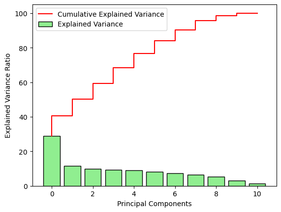

```python
# covariance matrix
covariance_matrix = np.cov(scaled_features.T)

# eigen values and eigen vector
eigen_vals, eigen_vectors = np.linalg.eig(covariance_matrix)

# scree plot
total = sum(eigen_vals)
variance_explained = [(i / total) * 100 for i in sorted(eigen_vals, reverse=True)]
cumulative_variance_explained = np.cumsum(variance_explained)

# Diagram
plt.bar(range(len(variance_explained)), variance_explained, align='center', color='lightgreen', edgecolor='black', label='Explained Variance')
plt.step(range(len(cumulative_variance_explained)), cumulative_variance_explained, color='red', label='Cumulative Explained Variance')
plt.xlabel('Principal Components')
plt.ylabel('Explained Variance Ratio')
plt.legend()
plt.show()
```

```python
# Fitting the PCA model
pca=PCA(n_components = 8)
pca.fit(scaled_features_df)
```

```
PCA(n_components=8)
```

```python
# transforming scaled data to principal components.
data_pca = pca.transform(scaled_features_df)
data_pca = pd.DataFrame(data_pca,columns=['PC1','PC2','PC3','PC4','PC5','PC6','PC7','PC8'])
data_pca.head()
```

|  | PC1 | PC2 | PC3 | PC4 | PC5 | PC6 | PC7 | PC8 |
| --- | --- | --- | --- | --- | --- | --- | --- | --- |
| 0 | 1.956902 | -0.081936 | -0.344667 | 1.193687 | -0.696970 | -0.299137 | -1.145041 | -0.358094 |
| 1 | -1.512598 | 1.000666 | -0.367106 | 1.006953 | -0.445000 | 1.371965 | -0.724374 | -0.346359 |
| 2 | 1.314538 | -0.299417 | 0.296366 | -0.764913 | 0.732877 | 0.984394 | 0.025389 | 0.058563 |
| 3 | -1.755094 | -1.139847 | -0.254499 | -0.825065 | 0.579217 | 0.221975 | 0.562426 | 0.239541 |
| 4 | 0.063584 | 0.571435 | 0.902243 | -0.757574 | -0.794825 | -1.241683 | 1.325626 | 0.898316 |

### 16. Apply K-means clustering and segment the data (Use PCA transformed data for clustering)

```python
# Define the range of cluster numbers to explore
cluster_range = range(2, 15)

# Create an empty list to store the cluster errors for each number of clusters
cluster_errors = []

# Iterate over each number of clusters in the defined range
for num_clusters in cluster_range:

    # Initialize KMeans clustering with the current number of clusters and a random state for reproducibility
    clusters = KMeans(num_clusters, random_state=100)

    # Fit the KMeans model to the PCA-transformed data
    clusters.fit(data_pca)

    # Calculate the inertia, which represents the sum of squared distances of samples to their closest cluster center
    cluster_errors.append(clusters.inertia_)

# Create a DataFrame to store the number of clusters and their corresponding cluster errors
clusters_df = pd.DataFrame({'num_clusters': cluster_range,
                             'cluster_errors': cluster_errors})

# Display the DataFrame containing the number of clusters and their corresponding errors
clusters_df
```

|  | num_clusters | cluster_errors |
| --- | --- | --- |
| 0 | 2 | 16858.827655 |
| 1 | 3 | 15441.611282 |
| 2 | 4 | 13346.337691 |
| 3 | 5 | 12282.105558 |
| 4 | 6 | 11219.191421 |
| 5 | 7 | 10574.262351 |
| 6 | 8 | 10029.890189 |
| 7 | 9 | 9608.377252 |
| 8 | 10 | 9216.858592 |
| 9 | 11 | 8915.657193 |
| 10 | 12 | 8707.977515 |
| 11 | 13 | 8413.161128 |
| 12 | 14 | 8212.312683 |

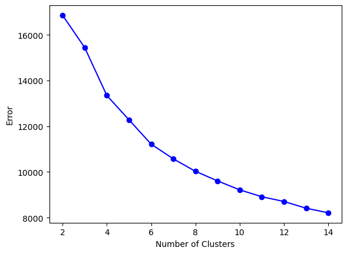

```python
# elbow plot
plt.plot(clusters_df['num_clusters'],clusters_df['cluster_errors'],marker='o',color='b')
plt.xlabel('Number of Clusters')
plt.ylabel('Error')
```

- Based on the elbow plot, between 3-6 clusters should be taken for KMeans clustering. The “elbow” point in the plot indicates that increasing the number of clusters beyond this point does not significantly reduce the error. Therefore, taking 3 to 6 clusters seem to strike a good balance between minimizing error and avoidinging overfitting.
- Proceeding with 3 clusters

```python
# Applying KMeans
# Fitting the KMeans clustering model using the obtained optimal K
kmeans = KMeans(n_clusters=3, random_state=100)
kmeans.fit(data_pca)
```

```
KMeans(n_clusters=3, random_state=100)
```

```python
# check cluster labels
label = pd.DataFrame(kmeans.labels_, columns=['Label'])

# joining the label column to pca data
kmeans_df = data_pca.join(label)
kmeans_df.head()
```

|  | PC1 | PC2 | PC3 | PC4 | PC5 | PC6 | PC7 | PC8 | Label |
| --- | --- | --- | --- | --- | --- | --- | --- | --- | --- |
| 0 | 1.956902 | -0.081936 | -0.344667 | 1.193687 | -0.696970 | -0.299137 | -1.145041 | -0.358094 | 0 |
| 1 | -1.512598 | 1.000666 | -0.367106 | 1.006953 | -0.445000 | 1.371965 | -0.724374 | -0.346359 | 1 |
| 2 | 1.314538 | -0.299417 | 0.296366 | -0.764913 | 0.732877 | 0.984394 | 0.025389 | 0.058563 | 0 |
| 3 | -1.755094 | -1.139847 | -0.254499 | -0.825065 | 0.579217 | 0.221975 | 0.562426 | 0.239541 | 1 |
| 4 | 0.063584 | 0.571435 | 0.902243 | -0.757574 | -0.794825 | -1.241683 | 1.325626 | 0.898316 | 2 |

```python
# data in each label
kmeans_df['Label'].value_counts()
```

```
Label
1    1023
2     704
0     513
Name: count, dtype: int64
```

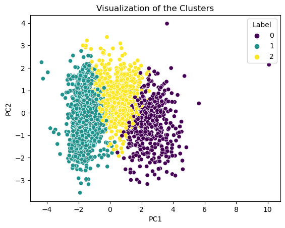

```python
# visualizing the clusters
sns.scatterplot(data=kmeans_df, x='PC1', y='PC2', hue='Label', palette='viridis')
plt.title('Visualization of the Clusters')
```

### 17. Apply Agglomerative clustering and segment the data (Use Original data for clustering), and perform cluster analysis by doing bivariate analysis between the cluster label and different features and write your observations.

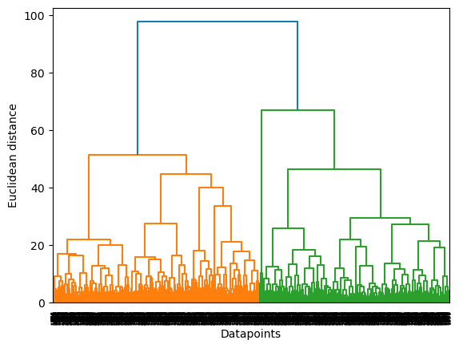

```python
# Compute the hierarchical clustering linkage matrix using Ward's method
merg = linkage(scaled_features, method='ward')

# Plot the dendrogram using the hierarchical clustering linkage matrix
dendrogram(merg, leaf_rotation=90)

# Display the dendrogram
plt.xlabel('Datapoints')
plt.ylabel('Euclidean distance')
plt.show()
```

```python
from sklearn.metrics import silhouette_score
```

```python
for i in range(2, 25):
    # Initialize AgglomerativeClustering with the current number of clusters (i)
    hierarchical_cl = AgglomerativeClustering(n_clusters=i)

    # Fit the AgglomerativeClustering model to the scaled features data
    hierarchical_cl = hierarchical_cl.fit(scaled_features_df)

    # Predict the cluster labels for each data point
    labels = hierarchical_cl.fit_predict(scaled_features_df)

    # Compute the silhouette score for the clustering result
    score = silhouette_score(scaled_features_df, labels)

    # Print the number of clusters and the corresponding silhouette score
    print(i, score)
```

```
2 0.19083932398841263
3 0.19859065923121116
4 0.11245037433445754
5 0.1142462175685332
6 0.13181821517770267
7 0.13957002140192074
8 0.1390706310270007
9 0.11337088108590954
10 0.11192131225156017
11 0.10382081162153395
12 0.10893099764800893
13 0.1023394958833542
14 0.09549869159604249
15 0.0991615711069726
16 0.09710952571690447
17 0.09489252379414646
18 0.09364631036627927
19 0.09198831621674032
20 0.09444749864898916
21 0.09485319565495526
22 0.0966801153165996
23 0.10011826448627932
24 0.10008982911463447
```

- The highest silhouette score is for 3 clusters (0.1986). Therefore, we should choose 3 clusters for your Agglomorative clustering.

```python
# Initialize AgglomerativeClustering with the pptimum number of clusters and linkage method
hier_cluster = AgglomerativeClustering(n_clusters=3, linkage='ward')

# Fit the AgglomerativeClustering model to the scaled features data
hier_cluster_model = hier_cluster.fit(scaled_features_df)
```

```python
## Creating a dataframe of the labels
df_label1 = pd.DataFrame(hier_cluster_model.labels_,columns=['Labels'])
df_label1.head(5)
```

|  | Labels |
| --- | --- |
| 0 | 0 |
| 1 | 1 |
| 2 | 0 |
| 3 | 1 |
| 4 | 0 |

```python
# joining the label dataframe with unscaled initial cleaned dataframe.(dfc)

df_hier = df_copy.join(df_label1)
df_hier.head()
```

|  | Education | Marital_Status | Income | Recency | NumWebVisitsMonth | Complain | Total_Expenses | Num_Total_Purchases | Kids | TotalAcceptedCmp | age | Labels |
| --- | --- | --- | --- | --- | --- | --- | --- | --- | --- | --- | --- | --- |
| 0 | Graduation | Single | 58138.0 | 58 | 7 | 0 | 1617 | 25 | 0 | 1 | 67 | 0 |
| 1 | Graduation | Single | 46344.0 | 38 | 5 | 0 | 27 | 6 | 2 | 0 | 70 | 1 |
| 2 | Graduation | relationship | 71613.0 | 26 | 4 | 0 | 776 | 21 | 0 | 0 | 59 | 0 |
| 3 | Graduation | relationship | 26646.0 | 26 | 6 | 0 | 53 | 8 | 1 | 0 | 40 | 1 |
| 4 | PhD | relationship | 58293.0 | 94 | 5 | 0 | 422 | 19 | 1 | 0 | 43 | 0 |

### Visualization and Interpretation of results

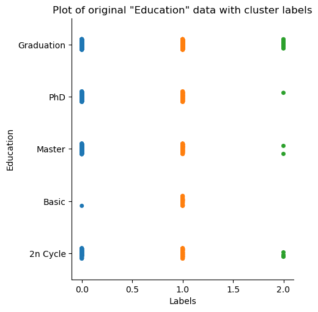

```python
# Cat plot of the 'Education' data vs 'cluster labels' colored by cluster labels
sns.catplot(x='Labels', y='Education', hue='Labels', data=df_hier, palette='tab10')
plt.title('Plot of original "Education" data with cluster labels')
plt.xlabel('Labels')
plt.ylabel('Education')
plt.show()
```

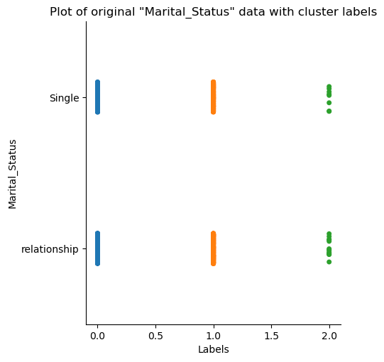

```python
# cat plot of the 'Marital_Status' vs cluster labels colored by cluster labels
sns.catplot(x='Labels', y='Marital_Status', hue='Labels', data=df_hier, palette='tab10')
plt.title('Plot of original "Marital_Status" data with cluster labels')
plt.xlabel('Labels')
plt.ylabel('Marital_Status')
plt.show()
```

## Interpretation

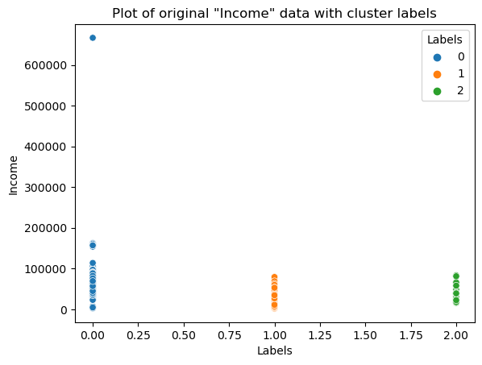

```python
# scatter plot of the 'Income' vs cluster labels colored by cluster labels
sns.scatterplot(x='Labels', y='Income', hue='Labels', data=df_hier, palette='tab10')
plt.title('Plot of original "Income" data with cluster labels')
plt.xlabel('Labels')
plt.ylabel('Income')
plt.show()
```

## Interpretation

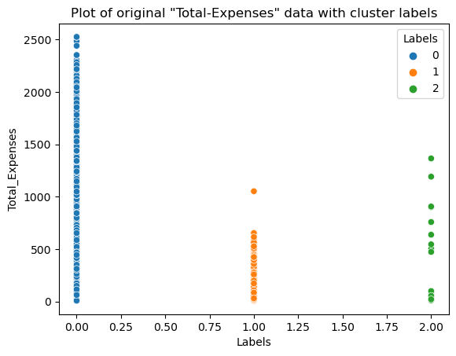

```python
# scatter plot of the 'Total_Expenses' vs cluster labels colored by cluster labels
sns.scatterplot(x='Labels', y='Total_Expenses', hue='Labels', data=df_hier, palette='tab10')
plt.title('Plot of original "Total-Expenses" data with cluster labels')
plt.xlabel('Labels')
plt.ylabel('Total_Expenses')
plt.show()
```

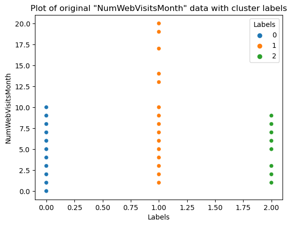

```python
# scatter plot of the 'Recency' vs cluster labels colored by cluster labels
sns.scatterplot(x='Labels', y='NumWebVisitsMonth', hue='Labels', data=df_hier, palette='tab10')
plt.title('Plot of original "NumWebVisitsMonth" data with cluster labels')
plt.xlabel('Labels')
plt.ylabel('NumWebVisitsMonth')
plt.show()
```

## Interpretation

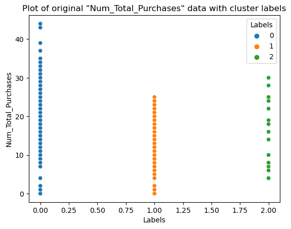

```python
# scatter plot of the 'NumTotalPurchases' vs cluster labels colored by cluster labels
sns.scatterplot(x='Labels', y='Num_Total_Purchases', hue='Labels', data=df_hier, palette='tab10')
plt.title('Plot of original "Num_Total_Purchases" data with cluster labels')
plt.xlabel('Labels')
plt.ylabel('Num_Total_Purchases')
plt.show()
```